# Decision Tree Classification — Exhaustive Visual Masterclass

## Notebook contract

This notebook is the **primary learning source**. Read it sequentially: every concept is derived, visualized, implemented, diagnosed, and interpreted. The dataset is deterministic synthetic teaching data; no result is evidence about real people.

## Learning architecture

**Path:** impurity → candidate splits → recursive partitions → stopping/pruning → probability leaves → threshold policy.

The workflow separates **ranking**, **probability estimation**, and **decision policy**. A strong classifier may still be poorly calibrated, and a threshold is an operational choice—not a mathematical constant.

## 1. Runtime and reproducibility

```python
from pathlib import Path
import json, math, platform, warnings
warnings.filterwarnings("ignore")

import joblib
import matplotlib.pyplot as plt
from IPython import get_ipython
get_ipython().run_line_magic("matplotlib", "inline")
import numpy as np
import pandas as pd
import scipy
import sklearn

from sklearn.base import clone
from sklearn.calibration import CalibrationDisplay, CalibratedClassifierCV
from sklearn.compose import ColumnTransformer
from sklearn.ensemble import BaggingClassifier, ExtraTreesClassifier, RandomForestClassifier
from sklearn.inspection import PartialDependenceDisplay, permutation_importance
from sklearn.linear_model import LogisticRegression
from sklearn.metrics import (
    accuracy_score, average_precision_score, balanced_accuracy_score,
    brier_score_loss, classification_report, confusion_matrix,
    ConfusionMatrixDisplay, f1_score, log_loss, matthews_corrcoef,
    precision_recall_curve, precision_score, recall_score, roc_auc_score,
    RocCurveDisplay, PrecisionRecallDisplay,
)
from sklearn.model_selection import (
    RandomizedSearchCV, RepeatedStratifiedKFold, StratifiedKFold,
    cross_validate, learning_curve, train_test_split,
)
from sklearn.pipeline import Pipeline
from sklearn.preprocessing import OneHotEncoder, StandardScaler
from sklearn.impute import SimpleImputer
from sklearn.tree import DecisionTreeClassifier, export_text, plot_tree

RANDOM_STATE = 4317
np.random.seed(RANDOM_STATE)
pd.set_option("display.max_columns", 100)
pd.set_option("display.width", 160)
plt.rcParams.update({"figure.figsize": (10, 5), "axes.grid": True, "figure.dpi": 110})
print({"python": platform.python_version(), "numpy": np.__version__, "pandas": pd.__version__, "scipy": scipy.__version__, "sklearn": sklearn.__version__})
```

```
{'python': '3.12.13', 'numpy': '2.3.5', 'pandas': '2.2.3', 'scipy': '1.17.0', 'sklearn': '1.8.0'}
```

## 2. Dataset provenance and first inspection

```python
DATA_PATH = Path("data/loan_default_teaching.csv")
if not DATA_PATH.exists():
    subprocess_result = __import__("subprocess").run([sys.executable, "scripts/generate_teaching_data.py"], check=True)
df = pd.read_csv(DATA_PATH)
TARGET = "default"
ID_COL = "customer_id"
print("shape:", df.shape)
display(df.head())
```

```
shape: (2400, 16)
```

|  | customer_id | age | annual_income | employment_years | credit_score | debt_ratio | missed_payments_12m | loan_amount | interest_rate | prior_default | home_ownership | purpose | region | channel | application_month | default |
| --- | --- | --- | --- | --- | --- | --- | --- | --- | --- | --- | --- | --- | --- | --- | --- | --- |
| 0 | CUST-00001 | 51 | 39533.76 | 3.7 | 598 | 0.469 | 0 | 4558.30 | 8.07 | 0 | RENT | debt_consolidation | north | branch | 10 | 0 |
| 1 | CUST-00002 | 55 | 125261.09 | 12.3 | 638 | 0.225 | 0 | 15241.73 | 5.31 | 0 | RENT | debt_consolidation | east | web | 12 | 0 |
| 2 | CUST-00003 | 67 | 58169.67 | 9.0 | 710 | 0.066 | 1 | 8504.40 | 4.39 | 0 | RENT | small_business | west | branch | 11 | 0 |
| 3 | CUST-00004 | 34 | 31365.51 | 5.2 | 648 | 0.548 | 0 | 8641.82 | 7.12 | 0 | OTHER | small_business | south | web | 6 | 0 |
| 4 | CUST-00005 | 34 | 147184.75 | 5.4 | 742 | 0.405 | 2 | 7387.29 | 5.92 | 0 | OWN | vehicle | west | partner | 11 | 0 |

## 3. Schema, missingness, duplicates, identifiers, and target audit

```python
audit = pd.DataFrame({
    "dtype": df.dtypes.astype(str),
    "missing_n": df.isna().sum(),
    "missing_pct": (100 * df.isna().mean()).round(2),
    "unique": df.nunique(dropna=False),
})
audit["role"] = np.where(audit.index == TARGET, "target", np.where(audit.index == ID_COL, "identifier", "predictor"))
display(audit)
print("duplicate rows:", int(df.duplicated().sum()))
print("duplicate ids:", int(df[ID_COL].duplicated().sum()))
print("target classes:", sorted(df[TARGET].unique().tolist()))
print("positive rate:", round(df[TARGET].mean(), 4))
assert set(df[TARGET].unique()) == {0, 1}
assert df[ID_COL].is_unique
```

|  | dtype | missing_n | missing_pct | unique | role |
| --- | --- | --- | --- | --- | --- |
| customer_id | object | 0 | 0.00 | 2400 | identifier |
| age | int64 | 0 | 0.00 | 50 | predictor |
| annual_income | float64 | 60 | 2.50 | 2322 | predictor |
| employment_years | float64 | 84 | 3.50 | 214 | predictor |
| credit_score | int64 | 0 | 0.00 | 352 | predictor |
| debt_ratio | float64 | 43 | 1.79 | 674 | predictor |
| missed_payments_12m | int64 | 0 | 0.00 | 6 | predictor |
| loan_amount | float64 | 0 | 0.00 | 2383 | predictor |
| interest_rate | float64 | 0 | 0.00 | 691 | predictor |
| prior_default | int64 | 0 | 0.00 | 2 | predictor |
| home_ownership | object | 28 | 1.17 | 5 | predictor |
| purpose | object | 0 | 0.00 | 6 | predictor |
| region | object | 0 | 0.00 | 4 | predictor |
| channel | object | 0 | 0.00 | 4 | predictor |
| application_month | int64 | 0 | 0.00 | 12 | predictor |
| default | int64 | 0 | 0.00 | 2 | target |

```
duplicate rows: 0
duplicate ids: 0
target classes: [0, 1]
positive rate: 0.0996
```

## 4. Metric strategy under class imbalance

Accuracy is reported but not trusted alone. ROC-AUC measures ranking, average precision emphasizes the minority class, Brier/log loss assess probability quality, and precision/recall/F1/MCC depend on a threshold.

## 5. Numerical EDA: distribution, outliers, class separation, ECDF

|  | count | mean | std | min | 1% | 5% | 25% | 50% | 75% | 95% | 99% | max | skew |
| --- | --- | --- | --- | --- | --- | --- | --- | --- | --- | --- | --- | --- | --- |
| age | 2400.0 | 41.521 | 10.654 | 21.00 | 21.000 | 23.000 | 34.000 | 41.000 | 49.000 | 60.000 | 66.010 | 70.000 | 0.105 |
| annual_income | 2340.0 | 69778.598 | 35246.510 | 18000.00 | 20610.188 | 28699.315 | 44822.012 | 61118.920 | 87322.898 | 137139.024 | 183466.145 | 240000.000 | 1.391 |
| employment_years | 2316.0 | 7.493 | 4.684 | 0.40 | 0.900 | 1.900 | 3.900 | 6.500 | 10.000 | 16.925 | 20.985 | 32.600 | 1.067 |
| credit_score | 2400.0 | 667.491 | 72.835 | 387.00 | 493.970 | 548.000 | 619.000 | 668.000 | 717.000 | 788.050 | 827.010 | 850.000 | -0.064 |
| debt_ratio | 2357.0 | 0.327 | 0.172 | 0.02 | 0.040 | 0.083 | 0.190 | 0.306 | 0.445 | 0.647 | 0.756 | 0.859 | 0.508 |
| missed_payments_12m | 2400.0 | 0.732 | 0.869 | 0.00 | 0.000 | 0.000 | 0.000 | 1.000 | 1.000 | 2.000 | 3.000 | 5.000 | 1.240 |
| loan_amount | 2400.0 | 21977.465 | 14969.992 | 1881.84 | 3958.714 | 6289.802 | 11632.658 | 17943.900 | 27737.880 | 51299.700 | 80430.351 | 90000.000 | 1.753 |
| interest_rate | 2400.0 | 6.962 | 1.815 | 3.50 | 3.500 | 3.918 | 5.640 | 6.940 | 8.202 | 10.070 | 11.291 | 14.090 | 0.192 |
| prior_default | 2400.0 | 0.097 | 0.296 | 0.00 | 0.000 | 0.000 | 0.000 | 0.000 | 0.000 | 1.000 | 1.000 | 1.000 | 2.732 |
| application_month | 2400.0 | 6.535 | 3.431 | 1.00 | 1.000 | 1.000 | 4.000 | 7.000 | 10.000 | 12.000 | 12.000 | 12.000 | -0.001 |

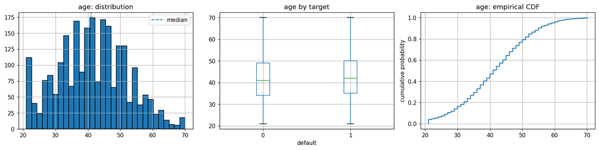

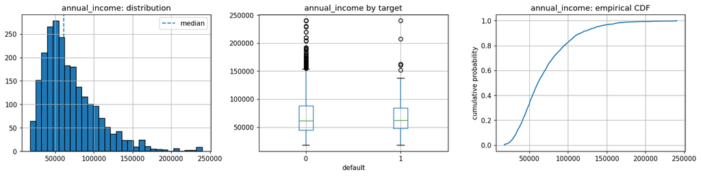

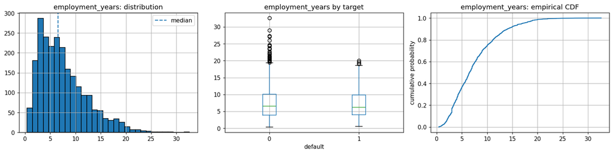

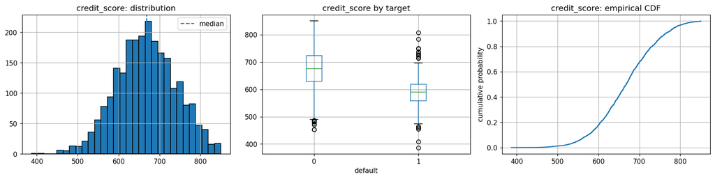

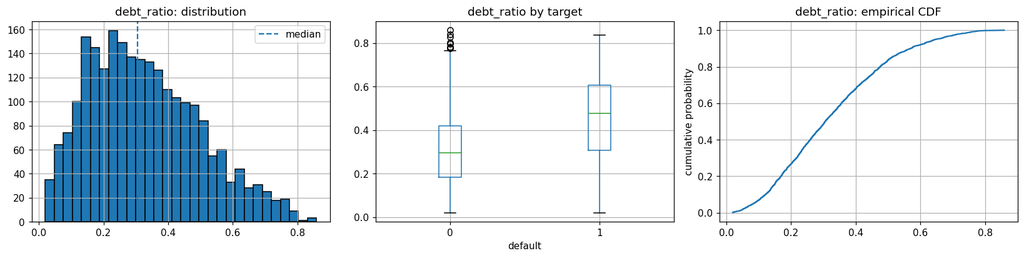

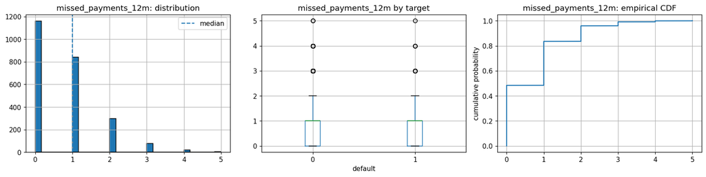

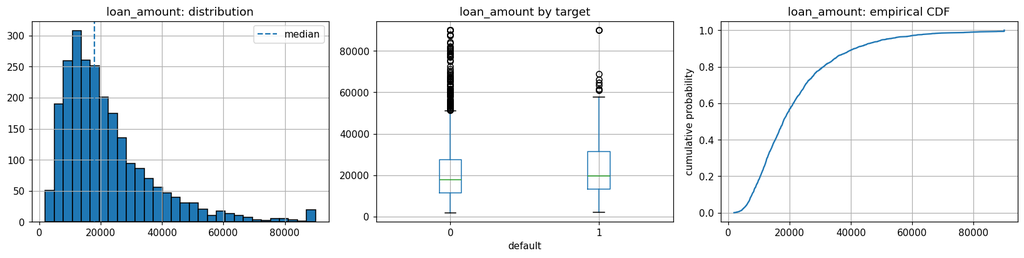

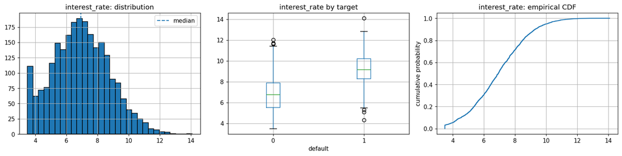

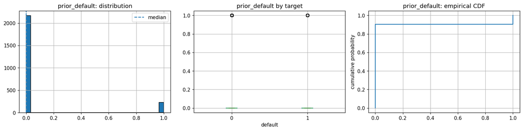

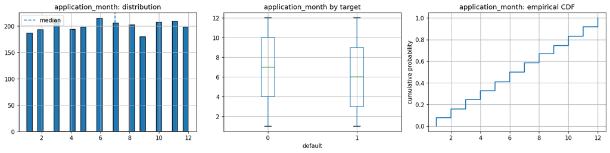

```python
model_df = df.drop(columns=ID_COL)
num_cols = [c for c in model_df.select_dtypes(include="number").columns if c != TARGET]
cat_cols = model_df.select_dtypes(exclude="number").columns.tolist()
summary = model_df[num_cols].describe(percentiles=[.01,.05,.25,.5,.75,.95,.99]).T
summary["skew"] = model_df[num_cols].skew()
display(summary.round(3))

for col in num_cols:
    values = model_df[col].dropna()
    fig, axes = plt.subplots(1, 3, figsize=(15, 4))
    axes[0].hist(values, bins=30, edgecolor="black")
    axes[0].axvline(values.median(), linestyle="--", label="median")
    axes[0].set_title(f"{col}: distribution"); axes[0].legend()
    model_df.boxplot(column=col, by=TARGET, ax=axes[1])
    axes[1].set_title(f"{col} by target"); axes[1].set_xlabel("default")
    sorted_v = np.sort(values)
    axes[2].plot(sorted_v, np.arange(1, len(sorted_v)+1)/len(sorted_v))
    axes[2].set_title(f"{col}: empirical CDF"); axes[2].set_ylabel("cumulative probability")
    plt.suptitle(""); plt.tight_layout(); plt.show()
```

## 6. Categorical EDA: support and conditional target rates

| home_ownership | default_rate | n |
| --- | --- | --- |
| OTHER | 14.08% | 71 |
| MORTGAGE | 10.60% | 972 |
| RENT | 10.25% | 946 |
| nan | 7.14% | 28 |
| OWN | 7.05% | 383 |

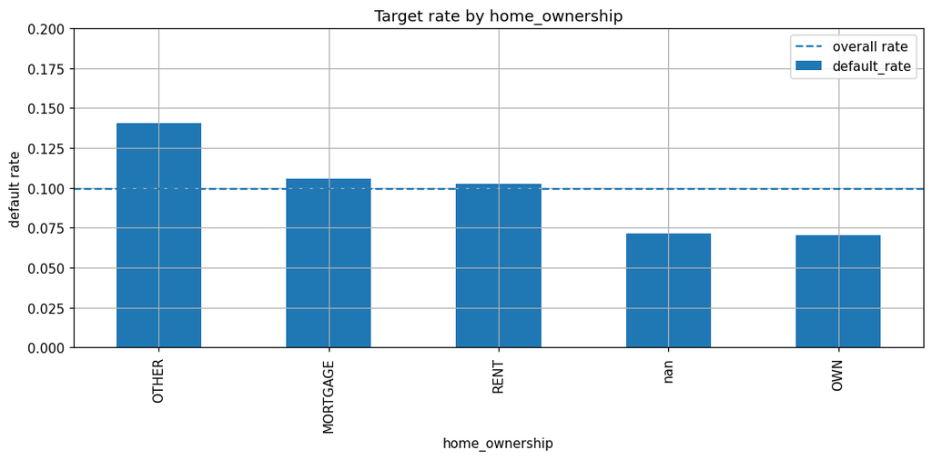

| purpose | default_rate | n |
| --- | --- | --- |
| vehicle | 11.44% | 402 |
| home_improvement | 11.05% | 344 |
| education | 9.79% | 235 |
| debt_consolidation | 9.44% | 953 |
| medical | 9.12% | 307 |
| small_business | 8.81% | 159 |

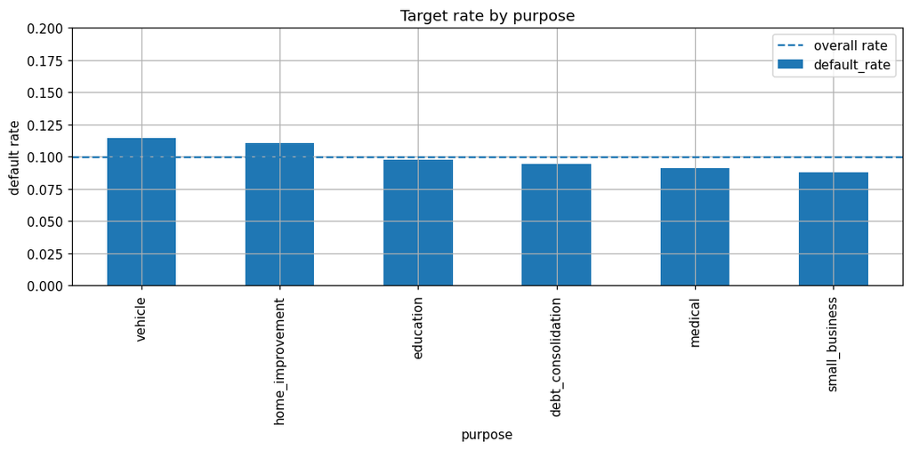

| region | default_rate | n |
| --- | --- | --- |
| south | 10.75% | 586 |
| west | 10.13% | 602 |
| north | 10.05% | 587 |
| east | 8.96% | 625 |

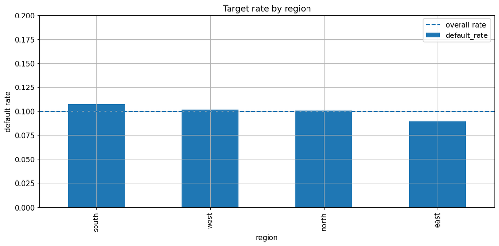

| channel | default_rate | n |
| --- | --- | --- |
| web | 11.61% | 956 |
| mobile | 9.75% | 513 |
| partner | 9.16% | 404 |
| branch | 7.78% | 527 |

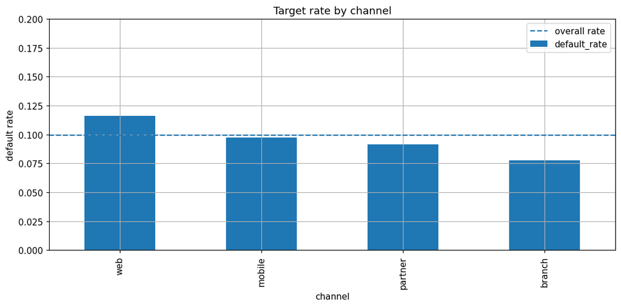

```python
for col in cat_cols:
    table = model_df.groupby(col, dropna=False)[TARGET].agg(default_rate="mean", n="size").sort_values("default_rate", ascending=False)
    display(table.style.format({"default_rate": "{:.2%}"}))
    ax = table["default_rate"].plot(kind="bar", ylim=(0, max(.2, table["default_rate"].max()*1.2)), title=f"Target rate by {col}")
    ax.axhline(model_df[TARGET].mean(), linestyle="--", label="overall rate")
    ax.set_ylabel("default rate"); ax.legend(); plt.tight_layout(); plt.show()
```

## 7. Multivariate structure and interaction evidence

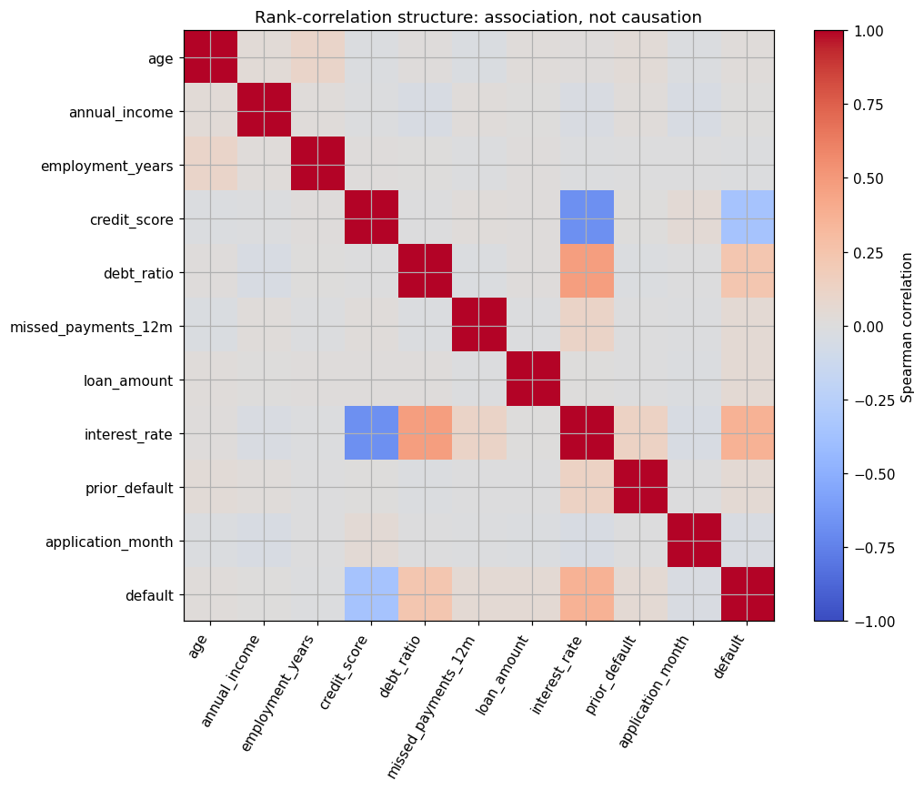

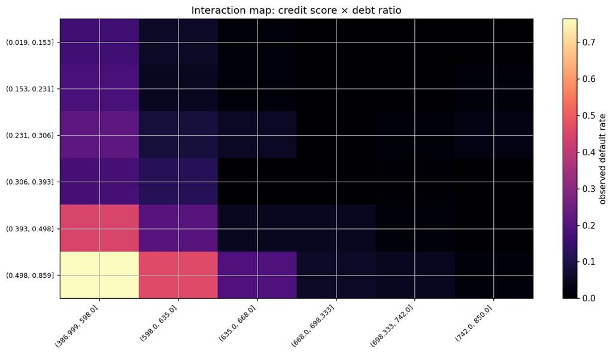

```python
corr = model_df[num_cols + [TARGET]].corr(method="spearman")
fig, ax = plt.subplots(figsize=(10, 8))
im = ax.imshow(corr, vmin=-1, vmax=1, cmap="coolwarm")
ax.set_xticks(range(len(corr))); ax.set_xticklabels(corr.columns, rotation=60, ha="right")
ax.set_yticks(range(len(corr))); ax.set_yticklabels(corr.index)
fig.colorbar(im, ax=ax, label="Spearman correlation")
ax.set_title("Rank-correlation structure: association, not causation")
plt.tight_layout(); plt.show()

credit_bins = pd.qcut(model_df["credit_score"], 6, duplicates="drop")
debt_bins = pd.qcut(model_df["debt_ratio"], 6, duplicates="drop")
heat = model_df.assign(credit_bin=credit_bins, debt_bin=debt_bins).pivot_table(index="debt_bin", columns="credit_bin", values=TARGET, aggfunc="mean", observed=False)
fig, ax = plt.subplots(figsize=(11, 6)); im = ax.imshow(heat, aspect="auto", cmap="magma")
ax.set_xticks(range(heat.shape[1])); ax.set_xticklabels([str(x) for x in heat.columns], rotation=45, ha="right", fontsize=8)
ax.set_yticks(range(heat.shape[0])); ax.set_yticklabels([str(x) for x in heat.index], fontsize=8)
fig.colorbar(im, ax=ax, label="observed default rate")
ax.set_title("Interaction map: credit score × debt ratio")
plt.tight_layout(); plt.show()
```

## 8. Leakage-safe train/validation/test contract

```python
X = model_df.drop(columns=TARGET)
y = model_df[TARGET].astype(int)
X_train_full, X_test, y_train_full, y_test = train_test_split(X, y, test_size=.20, stratify=y, random_state=RANDOM_STATE)
X_train, X_valid, y_train, y_valid = train_test_split(X_train_full, y_train_full, test_size=.25, stratify=y_train_full, random_state=RANDOM_STATE)
num_features = X.select_dtypes(include="number").columns.tolist()
cat_features = X.select_dtypes(exclude="number").columns.tolist()
preprocess = ColumnTransformer([
    ("num", SimpleImputer(strategy="median"), num_features),
    ("cat", Pipeline([
        ("imputer", SimpleImputer(strategy="most_frequent")),
        ("onehot", OneHotEncoder(handle_unknown="ignore", sparse_output=False)),
    ]), cat_features),
], verbose_feature_names_out=False)
print({"train": X_train.shape, "validation": X_valid.shape, "test": X_test.shape})
print("positive rates:", {"train": y_train.mean(), "validation": y_valid.mean(), "test": y_test.mean()})
```

```
{'train': (1440, 14), 'validation': (480, 14), 'test': (480, 14)}
positive rates: {'train': np.float64(0.09930555555555555), 'validation': np.float64(0.1), 'test': np.float64(0.1)}
```

## 9. Reusable evaluation functions

```python
def metric_row(name, y_true, proba, threshold=.5):
    pred = (np.asarray(proba) >= threshold).astype(int)
    return {
        "model": name, "threshold": threshold,
        "accuracy": accuracy_score(y_true, pred),
        "balanced_accuracy": balanced_accuracy_score(y_true, pred),
        "precision": precision_score(y_true, pred, zero_division=0),
        "recall": recall_score(y_true, pred, zero_division=0),
        "f1": f1_score(y_true, pred, zero_division=0),
        "mcc": matthews_corrcoef(y_true, pred),
        "roc_auc": roc_auc_score(y_true, proba),
        "average_precision": average_precision_score(y_true, proba),
        "log_loss": log_loss(y_true, np.clip(proba, 1e-6, 1-1e-6)),
        "brier": brier_score_loss(y_true, proba),
    }

def evaluate_model(name, model, X_ref=X_valid, y_ref=y_valid, threshold=.5):
    return metric_row(name, y_ref, model.predict_proba(X_ref)[:, 1], threshold)

def plot_classifier_diagnostics(model, X_ref, y_ref, title):
    fig, axes = plt.subplots(1, 3, figsize=(16, 4))
    ConfusionMatrixDisplay.from_estimator(model, X_ref, y_ref, ax=axes[0])
    RocCurveDisplay.from_estimator(model, X_ref, y_ref, ax=axes[1])
    PrecisionRecallDisplay.from_estimator(model, X_ref, y_ref, ax=axes[2])
    axes[0].set_title("Confusion matrix"); axes[1].set_title("ROC curve"); axes[2].set_title("Precision-recall curve")
    fig.suptitle(title); plt.tight_layout(); plt.show()
```

## 10. CART mechanics from first principles

For node class proportions $p_k$, Gini impurity is $1-\sum_kp_k^2$ and entropy is $-\sum_kp_k\log_2p_k$. A split is valuable only when the weighted child impurity is lower than the parent impurity. Misclassification error is less sensitive and is usually not the split criterion.

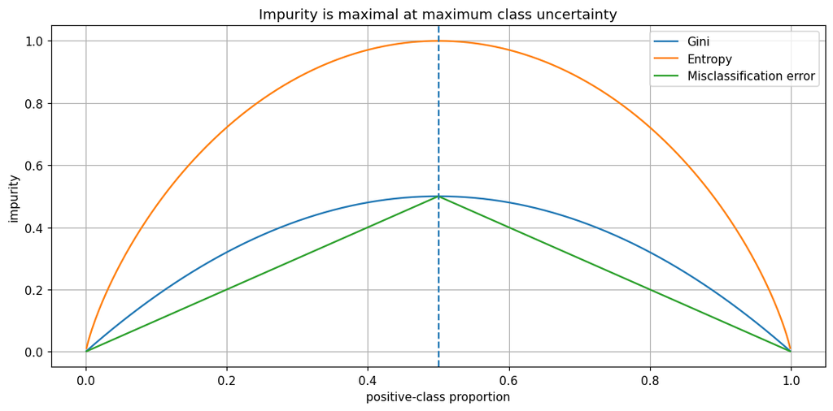

```python
p = np.linspace(.001,.999,400)
gini_curve = 2*p*(1-p)
entropy_curve = -(p*np.log2(p)+(1-p)*np.log2(1-p))
misclass_curve = np.minimum(p,1-p)
plt.plot(p,gini_curve,label="Gini"); plt.plot(p,entropy_curve,label="Entropy"); plt.plot(p,misclass_curve,label="Misclassification error")
plt.axvline(.5,linestyle="--"); plt.xlabel("positive-class proportion"); plt.ylabel("impurity"); plt.title("Impurity is maximal at maximum class uncertainty"); plt.legend(); plt.tight_layout(); plt.show()
```

## 11. Manual numerical split search and inference

|  | threshold | gain | left_n | right_n | left_rate | right_rate |
| --- | --- | --- | --- | --- | --- | --- |
| 65 | 0.469000 | 0.012383 | 1120 | 295 | 0.057143 | 0.250847 |
| 64 | 0.459667 | 0.011469 | 1102 | 313 | 0.057169 | 0.239617 |
| 63 | 0.455000 | 0.011439 | 1088 | 327 | 0.056066 | 0.235474 |
| 66 | 0.476885 | 0.011388 | 1134 | 281 | 0.059965 | 0.249110 |
| 67 | 0.483994 | 0.011116 | 1150 | 265 | 0.061739 | 0.252830 |
| 75 | 0.574000 | 0.011004 | 1280 | 135 | 0.073438 | 0.325926 |
| 58 | 0.415000 | 0.010971 | 1009 | 406 | 0.050545 | 0.214286 |
| 56 | 0.402000 | 0.010838 | 976 | 439 | 0.048156 | 0.207289 |
| 62 | 0.447000 | 0.010726 | 1071 | 344 | 0.056022 | 0.226744 |
| 68 | 0.494000 | 0.010496 | 1168 | 247 | 0.064212 | 0.255061 |

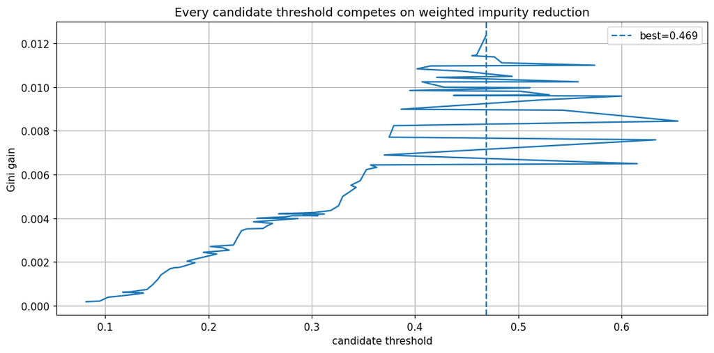

```python
def gini(yv):
    counts=np.bincount(np.asarray(yv,dtype=int),minlength=2); p=counts/counts.sum(); return 1-np.sum(p*p)
def split_scan(feature):
    tmp=pd.DataFrame({"x":X_train[feature],"y":y_train}).dropna().sort_values("x")
    candidates=np.unique(np.quantile(tmp.x,np.linspace(.05,.95,80)))
    parent=gini(tmp.y); rows=[]
    for t in candidates:
        left=tmp[tmp.x<=t].y; right=tmp[tmp.x>t].y
        if min(len(left),len(right))<20: continue
        child=len(left)/len(tmp)*gini(left)+len(right)/len(tmp)*gini(right)
        rows.append({"threshold":t,"gain":parent-child,"left_n":len(left),"right_n":len(right),"left_rate":left.mean(),"right_rate":right.mean()})
    return pd.DataFrame(rows).sort_values("gain",ascending=False)
scan=split_scan("debt_ratio"); display(scan.head(10))
best=scan.iloc[0]
plt.plot(scan.threshold,scan.gain); plt.axvline(best.threshold,linestyle="--",label=f"best={best.threshold:.3f}")
plt.title("Every candidate threshold competes on weighted impurity reduction"); plt.xlabel("candidate threshold"); plt.ylabel("Gini gain"); plt.legend(); plt.tight_layout(); plt.show()
```

## 12. Manual categorical split logic

CART partitions categories into two groups. One-hot encoding turns this into transparent yes/no membership tests. Rare categories require caution because high apparent gain may be sampling noise.

| purpose | mean | count |
| --- | --- | --- |
| medical | 0.072917 | 192 |
| education | 0.090226 | 133 |
| small_business | 0.097826 | 92 |
| debt_consolidation | 0.102564 | 585 |
| vehicle | 0.103306 | 242 |
| home_improvement | 0.117347 | 196 |

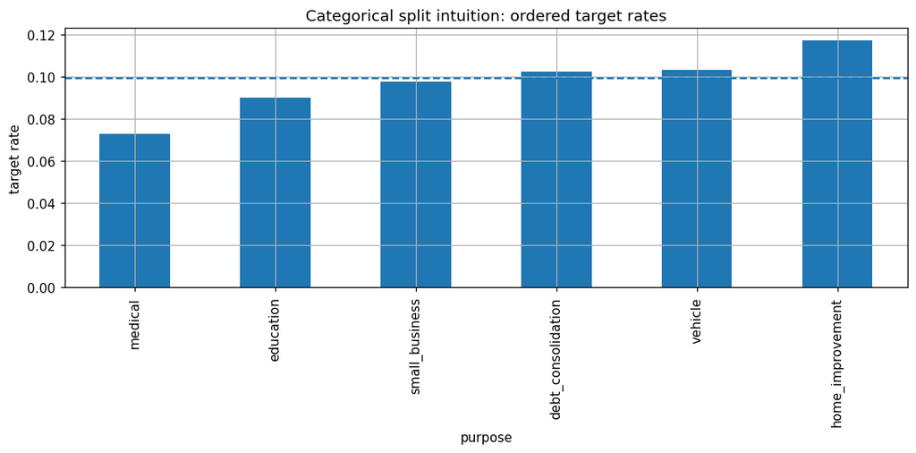

```python
rates=X_train.assign(target=y_train.values).groupby("purpose").target.agg(["mean","count"]).sort_values("mean")
display(rates)
rates["mean"].plot(kind="bar",title="Categorical split intuition: ordered target rates")
plt.axhline(y_train.mean(),linestyle="--"); plt.ylabel("target rate"); plt.tight_layout(); plt.show()
```

## 13. A decision stump from scratch

```python
class NumericDecisionStump:
    def fit(self, x, y):
        table=pd.DataFrame({"x":x,"y":y}).dropna(); self.fill_=table.x.median(); table.x=table.x.fillna(self.fill_)
        candidates=np.unique(np.quantile(table.x,np.linspace(.05,.95,100))); parent=gini(table.y); best=None
        for t in candidates:
            left=table[table.x<=t].y; right=table[table.x>t].y
            if min(len(left),len(right))<15: continue
            gain=parent-(len(left)*gini(left)+len(right)*gini(right))/len(table)
            if best is None or gain>best[0]: best=(gain,t,left.mean(),right.mean())
        self.gain_,self.threshold_,self.left_probability_,self.right_probability_=best; return self
    def predict_proba(self,x):
        x=pd.Series(x).fillna(self.fill_).to_numpy(); p=np.where(x<=self.threshold_,self.left_probability_,self.right_probability_); return np.c_[1-p,p]
stump=NumericDecisionStump().fit(X_train.credit_score,y_train)
print(vars(stump)); display(pd.DataFrame([metric_row("scratch_stump",y_valid,stump.predict_proba(X_valid.credit_score)[:,1])]))
```

```
{'fill_': np.float64(665.5), 'gain_': np.float64(0.028003324005066194), 'threshold_': np.float64(608.0), 'left_probability_': np.float64(0.3247588424437299), 'right_probability_': np.float64(0.03720106288751107)}
```

|  | model | threshold | accuracy | balanced_accuracy | precision | recall | f1 | mcc | roc_auc | average_precision | log_loss | brier |
| --- | --- | --- | --- | --- | --- | --- | --- | --- | --- | --- | --- | --- |
| 0 | scratch_stump | 0.5 | 0.9 | 0.5 | 0.0 | 0.0 | 0.0 | 0.0 | 0.763889 | 0.265217 | 0.263159 | 0.075552 |

## 14. Baseline ladder: majority, logistic, shallow tree, unconstrained tree

|  | model | threshold | accuracy | balanced_accuracy | precision | recall | f1 | mcc | roc_auc | average_precision | log_loss | brier |
| --- | --- | --- | --- | --- | --- | --- | --- | --- | --- | --- | --- | --- |
| 1 | logistic | 0.5 | 0.791667 | 0.782407 | 0.293651 | 0.770833 | 0.425287 | 0.385107 | 0.857591 | 0.422886 | 0.444243 | 0.144540 |
| 2 | tree_depth4 | 0.5 | 0.793750 | 0.755787 | 0.285714 | 0.708333 | 0.407186 | 0.355422 | 0.772111 | 0.410884 | 0.533231 | 0.140061 |
| 3 | tree_unconstrained | 0.5 | 0.860417 | 0.598380 | 0.288889 | 0.270833 | 0.279570 | 0.202510 | 0.598380 | 0.151157 | 1.928416 | 0.139583 |
| 0 | majority | 0.5 | 0.900000 | 0.500000 | 0.000000 | 0.000000 | 0.000000 | 0.000000 | 0.500000 | 0.100000 | 0.325086 | 0.090000 |

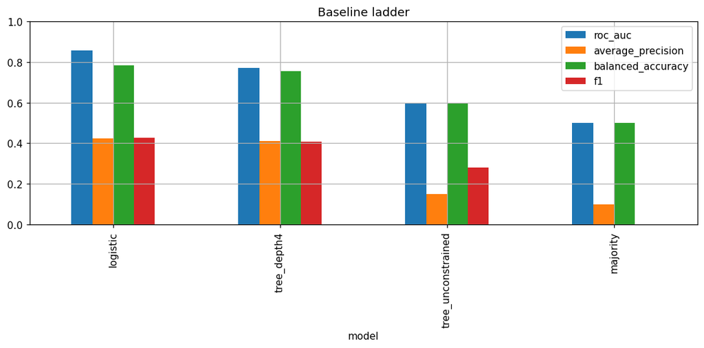

```python
models={
 "logistic":Pipeline([("preprocess",preprocess),("model",LogisticRegression(max_iter=2000,class_weight="balanced"))]),
 "tree_depth4":Pipeline([("preprocess",preprocess),("model",DecisionTreeClassifier(max_depth=4,min_samples_leaf=25,class_weight="balanced",random_state=RANDOM_STATE))]),
 "tree_unconstrained":Pipeline([("preprocess",preprocess),("model",DecisionTreeClassifier(class_weight="balanced",random_state=RANDOM_STATE))]),
}
rows=[]
majority=np.repeat(y_train.mode().iloc[0],len(y_valid)); majority_proba=np.repeat(y_train.mean(),len(y_valid)); rows.append(metric_row("majority",y_valid,majority_proba))
for name,model in models.items(): model.fit(X_train,y_train); rows.append(evaluate_model(name,model))
comparison=pd.DataFrame(rows).sort_values("roc_auc",ascending=False); display(comparison)
comparison.set_index("model")[["roc_auc","average_precision","balanced_accuracy","f1"]].plot(kind="bar",ylim=(0,1),title="Baseline ladder")
plt.tight_layout(); plt.show()
```

## 15. Capacity diagnostics: depth and minimum leaf size

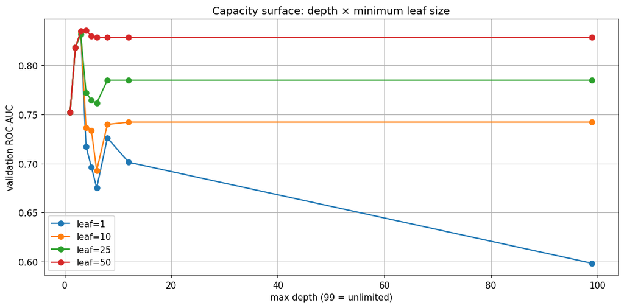

```python
rows=[]
for depth in [1,2,3,4,5,6,8,12,None]:
 for leaf in [1,10,25,50]:
  m=Pipeline([("preprocess",preprocess),("model",DecisionTreeClassifier(max_depth=depth,min_samples_leaf=leaf,class_weight="balanced",random_state=RANDOM_STATE))])
  m.fit(X_train,y_train)
  rows.append({"depth":99 if depth is None else depth,"leaf":leaf,"train_auc":roc_auc_score(y_train,m.predict_proba(X_train)[:,1]),"valid_auc":roc_auc_score(y_valid,m.predict_proba(X_valid)[:,1])})
capacity=pd.DataFrame(rows)
for leaf,part in capacity.groupby("leaf"):
 plt.plot(part.depth,part.valid_auc,marker="o",label=f"leaf={leaf}")
plt.xlabel("max depth (99 = unlimited)"); plt.ylabel("validation ROC-AUC"); plt.title("Capacity surface: depth × minimum leaf size"); plt.legend(); plt.tight_layout(); plt.show()
```

## 16. Cost-complexity pruning path

|  | alpha | nodes | depth | train_auc | valid_auc |
| --- | --- | --- | --- | --- | --- |
| 28 | 0.010168 | 9 | 3 | 0.874889 | 0.810137 |
| 27 | 0.007286 | 15 | 4 | 0.904861 | 0.762249 |
| 29 | 0.056555 | 3 | 1 | 0.795286 | 0.752315 |
| 18 | 0.002225 | 95 | 11 | 0.972033 | 0.725092 |
| 17 | 0.002008 | 99 | 11 | 0.973888 | 0.723235 |

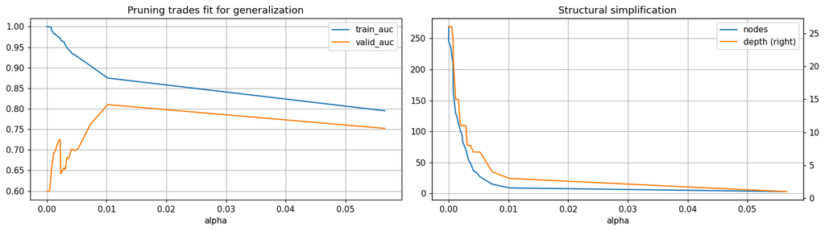

```python
prep=clone(preprocess); Xt=prep.fit_transform(X_train); Xv=prep.transform(X_valid)
base_tree=DecisionTreeClassifier(class_weight="balanced",random_state=RANDOM_STATE).fit(Xt,y_train)
path=base_tree.cost_complexity_pruning_path(Xt,y_train)
alphas=np.unique(np.quantile(path.ccp_alphas[:-1],np.linspace(0,1,30)))
rows=[]
for a in alphas:
 t=DecisionTreeClassifier(ccp_alpha=float(a),class_weight="balanced",random_state=RANDOM_STATE).fit(Xt,y_train)
 rows.append({"alpha":a,"nodes":t.tree_.node_count,"depth":t.get_depth(),"train_auc":roc_auc_score(y_train,t.predict_proba(Xt)[:,1]),"valid_auc":roc_auc_score(y_valid,t.predict_proba(Xv)[:,1])})
prune=pd.DataFrame(rows); display(prune.sort_values("valid_auc",ascending=False).head())
fig,axes=plt.subplots(1,2,figsize=(14,4)); prune.plot(x="alpha",y=["train_auc","valid_auc"],ax=axes[0]); prune.plot(x="alpha",y=["nodes","depth"],secondary_y="depth",ax=axes[1]); axes[0].set_title("Pruning trades fit for generalization"); axes[1].set_title("Structural simplification"); plt.tight_layout(); plt.show()
```

## 17. Cross-validated hyperparameter search

```python
base=Pipeline([("preprocess",preprocess),("model",DecisionTreeClassifier(class_weight="balanced",random_state=RANDOM_STATE))])
search=RandomizedSearchCV(base,{"model__criterion":["gini","entropy","log_loss"],"model__max_depth":[3,4,5,6,8,12,None],"model__min_samples_split":[2,10,25,50],"model__min_samples_leaf":[5,10,20,35,50],"model__max_features":[None,"sqrt",.7],"model__ccp_alpha":[0,.0005,.001,.002,.004]},n_iter=25,scoring="roc_auc",cv=StratifiedKFold(5,shuffle=True,random_state=RANDOM_STATE),random_state=RANDOM_STATE,n_jobs=1,return_train_score=True)
search.fit(X_train_full,y_train_full); selected_model=search.best_estimator_
print("best CV AUC:",search.best_score_); print(search.best_params_)
cv_results=pd.DataFrame(search.cv_results_).sort_values("rank_test_score").head(15); display(cv_results[["mean_train_score","mean_test_score","std_test_score","params"]])
```

```
best CV AUC: 0.8670808813296347
{'model__min_samples_split': 50, 'model__min_samples_leaf': 50, 'model__max_features': None, 'model__max_depth': 8, 'model__criterion': 'gini', 'model__ccp_alpha': 0.004}
```

|  | mean_train_score | mean_test_score | std_test_score | params |
| --- | --- | --- | --- | --- |
| 8 | 0.898557 | 0.867081 | 0.021759 | {'model__min_samples_split': 50, 'model__min_s... |
| 19 | 0.903096 | 0.865351 | 0.028451 | {'model__min_samples_split': 2, 'model__min_sa... |
| 15 | 0.890140 | 0.865292 | 0.019241 | {'model__min_samples_split': 50, 'model__min_s... |
| 7 | 0.912437 | 0.857277 | 0.028427 | {'model__min_samples_split': 50, 'model__min_s... |
| 5 | 0.929121 | 0.844652 | 0.030729 | {'model__min_samples_split': 50, 'model__min_s... |
| 24 | 0.916159 | 0.839082 | 0.033597 | {'model__min_samples_split': 10, 'model__min_s... |
| 20 | 0.917458 | 0.838668 | 0.027747 | {'model__min_samples_split': 10, 'model__min_s... |
| 12 | 0.938362 | 0.836042 | 0.021584 | {'model__min_samples_split': 50, 'model__min_s... |
| 4 | 0.912220 | 0.833070 | 0.018427 | {'model__min_samples_split': 10, 'model__min_s... |
| 3 | 0.924363 | 0.832812 | 0.030607 | {'model__min_samples_split': 10, 'model__min_s... |
| 21 | 0.913072 | 0.830602 | 0.020092 | {'model__min_samples_split': 50, 'model__min_s... |
| 18 | 0.922819 | 0.829681 | 0.043659 | {'model__min_samples_split': 25, 'model__min_s... |
| 11 | 0.918943 | 0.829224 | 0.018414 | {'model__min_samples_split': 50, 'model__min_s... |
| 1 | 0.933196 | 0.826132 | 0.024077 | {'model__min_samples_split': 25, 'model__min_s... |
| 2 | 0.930689 | 0.825943 | 0.028150 | {'model__min_samples_split': 25, 'model__min_s... |

## 18. Repeated-CV stability and learning curve

|  | count | mean | std | min | 25% | 50% | 75% | max |
| --- | --- | --- | --- | --- | --- | --- | --- | --- |
| auc | 15.0 | 0.866848 | 0.023399 | 0.828795 | 0.851213 | 0.866258 | 0.883671 | 0.906412 |
| ap | 15.0 | 0.398735 | 0.045000 | 0.327882 | 0.372338 | 0.395727 | 0.428050 | 0.477908 |
| bal | 15.0 | 0.796991 | 0.022461 | 0.769319 | 0.781048 | 0.789398 | 0.806472 | 0.845224 |

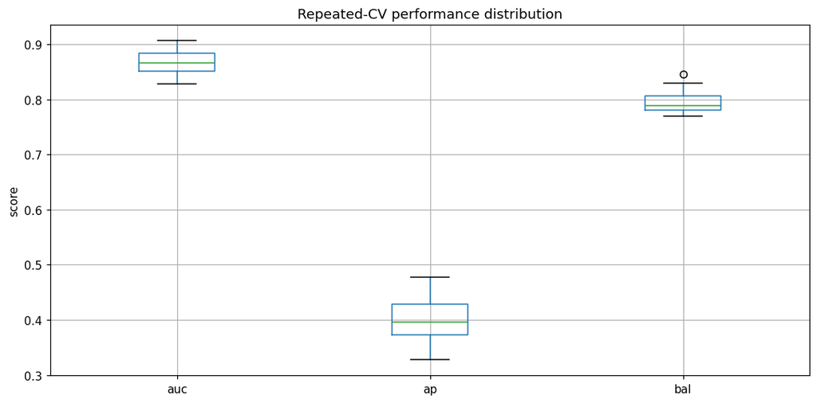

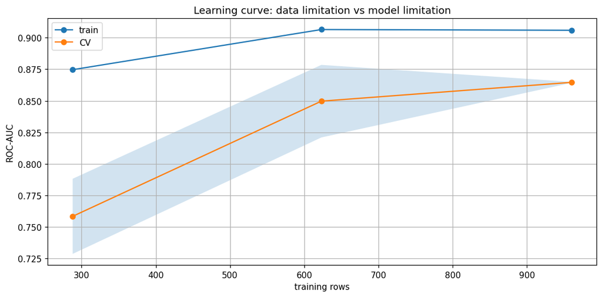

```python
cv=RepeatedStratifiedKFold(n_splits=5,n_repeats=3,random_state=RANDOM_STATE)
scores=cross_validate(selected_model,X_train_full,y_train_full,cv=cv,scoring={"auc":"roc_auc","ap":"average_precision","bal":"balanced_accuracy"},n_jobs=1)
stability=pd.DataFrame({k.replace("test_",""):v for k,v in scores.items() if k.startswith("test_")}); display(stability.describe().T)
stability.boxplot(); plt.title("Repeated-CV performance distribution"); plt.ylabel("score"); plt.tight_layout(); plt.show()
sizes,tr,va=learning_curve(selected_model,X_train_full,y_train_full,train_sizes=np.linspace(.3,1,3),cv=StratifiedKFold(2,shuffle=True,random_state=RANDOM_STATE),scoring="roc_auc",n_jobs=1)
plt.plot(sizes,tr.mean(1),marker="o",label="train"); plt.plot(sizes,va.mean(1),marker="o",label="CV"); plt.fill_between(sizes,va.mean(1)-va.std(1),va.mean(1)+va.std(1),alpha=.2); plt.xlabel("training rows"); plt.ylabel("ROC-AUC"); plt.title("Learning curve: data limitation vs model limitation"); plt.legend(); plt.tight_layout(); plt.show()
```

## 19. Tree structure, rules, local paths, and leaf audit

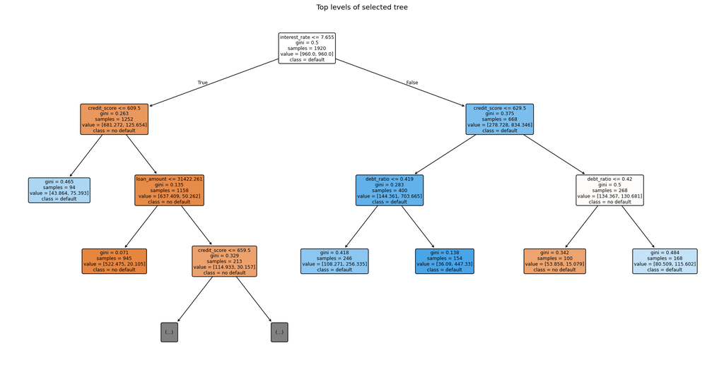

```
|--- interest_rate <= 7.65
|   |--- credit_score <= 609.50
|   |   |--- class: 1
|   |--- credit_score >  609.50
|   |   |--- loan_amount <= 31422.26
|   |   |   |--- class: 0
|   |   |--- loan_amount >  31422.26
|   |   |   |--- credit_score <= 659.50
|   |   |   |   |--- class: 0
|   |   |   |--- credit_score >  659.50
|   |   |   |   |--- class: 0
|--- interest_rate >  7.65
|   |--- credit_score <= 629.50
|   |   |--- debt_ratio <= 0.42
|   |   |   |--- class: 1
|   |   |--- debt_ratio >  0.42
|   |   |   |--- class: 1
|   |--- credit_score >  629.50
|   |   |--- debt_ratio <= 0.42
|   |   |   |--- class: 0
|   |   |--- debt_ratio >  0.42
|   |   |   |--- class: 1

record 0: leaf=2, path nodes=[0, 1, 2]
record 1: leaf=14, path nodes=[0, 8, 12, 14]
record 2: leaf=4, path nodes=[0, 1, 3, 4]
```

| leaf | size | mean |
| --- | --- | --- |
| 4 | 945 | 0.004233 |
| 10 | 246 | 0.207317 |
| 14 | 168 | 0.136905 |
| 7 | 161 | 0.006211 |
| 11 | 154 | 0.577922 |
| 13 | 100 | 0.030000 |
| 2 | 94 | 0.159574 |
| 6 | 52 | 0.096154 |

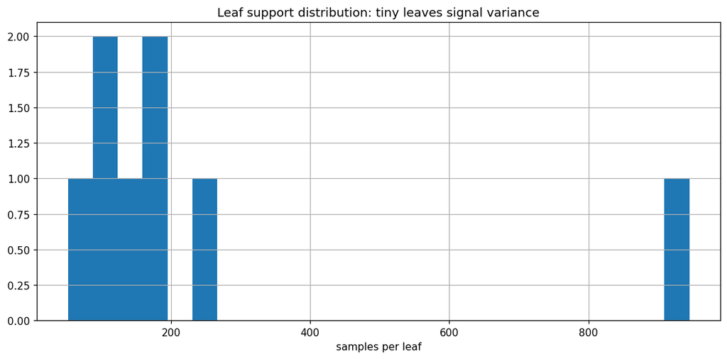

```python
selected_model.fit(X_train_full,y_train_full)
feature_names=selected_model.named_steps["preprocess"].get_feature_names_out(); tree=selected_model.named_steps["model"]
plt.figure(figsize=(22,11)); plot_tree(tree,feature_names=feature_names,class_names=["no default","default"],max_depth=3,filled=True,rounded=True,fontsize=8); plt.title("Top levels of selected tree"); plt.show()
print(export_text(tree,feature_names=list(feature_names),max_depth=4))
Xt_full=selected_model.named_steps["preprocess"].transform(X_train_full); Xv=selected_model.named_steps["preprocess"].transform(X_valid)
path=tree.decision_path(Xv[:3]); leaves=tree.apply(Xv[:3])
for i in range(3): print(f"record {i}: leaf={leaves[i]}, path nodes={path.indices[path.indptr[i]:path.indptr[i+1]].tolist()}")
leaf_id=tree.apply(Xt_full); leaf_table=pd.DataFrame({"leaf":leaf_id,"y":y_train_full.values}).groupby("leaf").y.agg(["size","mean"]).sort_values("size",ascending=False); display(leaf_table.head(15))
leaf_table["size"].hist(bins=25); plt.title("Leaf support distribution: tiny leaves signal variance"); plt.xlabel("samples per leaf"); plt.tight_layout(); plt.show()
```

## 20. Global importance: impurity vs permutation

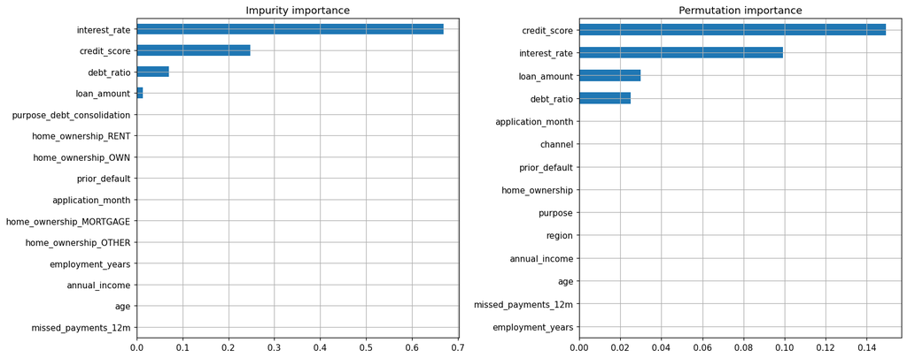

|  | permutation_auc_drop |
| --- | --- |
| credit_score | 0.149405 |
| interest_rate | 0.099169 |
| loan_amount | 0.029882 |
| debt_ratio | 0.025192 |
| annual_income | 0.000000 |
| age | 0.000000 |
| missed_payments_12m | 0.000000 |
| employment_years | 0.000000 |
| prior_default | 0.000000 |
| home_ownership | 0.000000 |
| purpose | 0.000000 |
| region | 0.000000 |
| channel | 0.000000 |
| application_month | 0.000000 |

```python
mdi=pd.Series(tree.feature_importances_,index=feature_names,name="MDI").sort_values(ascending=False)
perm=permutation_importance(selected_model,X_valid,y_valid,scoring="roc_auc",n_repeats=8,random_state=RANDOM_STATE,n_jobs=1)
perm_s=pd.Series(perm.importances_mean,index=X_valid.columns,name="permutation_auc_drop").sort_values(ascending=False)
fig,axes=plt.subplots(1,2,figsize=(15,6)); mdi.head(15).sort_values().plot(kind="barh",ax=axes[0],title="Impurity importance"); perm_s.head(15).sort_values().plot(kind="barh",ax=axes[1],title="Permutation importance"); plt.tight_layout(); plt.show(); display(perm_s.to_frame())
```

## 21. Partial dependence: conditional model response, not causality

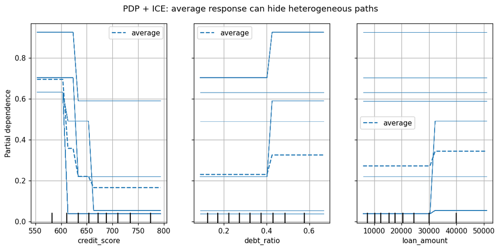

```python
PartialDependenceDisplay.from_estimator(selected_model,X_valid,["credit_score","debt_ratio","loan_amount"],kind="both",subsample=200,random_state=RANDOM_STATE,grid_resolution=25)
plt.suptitle("PDP + ICE: average response can hide heterogeneous paths"); plt.tight_layout(); plt.show()
```

## 22. Validation diagnostics before probability calibration

|  | model | threshold | accuracy | balanced_accuracy | precision | recall | f1 | mcc | roc_auc | average_precision | log_loss | brier |
| --- | --- | --- | --- | --- | --- | --- | --- | --- | --- | --- | --- | --- |
| 0 | selected_tree | 0.5 | 0.741667 | 0.810185 | 0.265432 | 0.895833 | 0.409524 | 0.393589 | 0.890408 | 0.443992 | 0.384978 | 0.133423 |

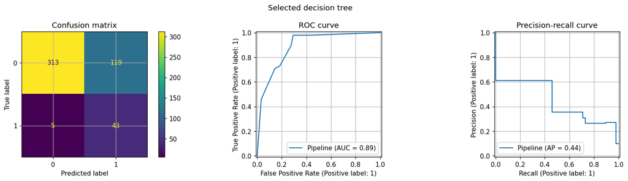

```python
display(pd.DataFrame([evaluate_model("selected_tree",selected_model)])); plot_classifier_diagnostics(selected_model,X_valid,y_valid,"Selected decision tree")
```

## 23. Calibration

|  | model | roc_auc | average_precision | log_loss | brier |
| --- | --- | --- | --- | --- | --- |
| 0 | raw | 0.890408 | 0.443992 | 0.384978 | 0.133423 |
| 1 | sigmoid_calibrated | 0.848717 | 0.410874 | 0.239558 | 0.070432 |

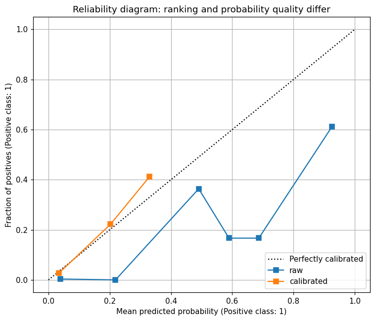

```python
raw_proba = selected_model.predict_proba(X_valid)[:, 1]
calibrated_model = CalibratedClassifierCV(clone(selected_model), method="sigmoid", cv=2)
calibrated_model.fit(X_train, y_train)
cal_proba = calibrated_model.predict_proba(X_valid)[:, 1]
cal_table = pd.DataFrame([
    metric_row("raw", y_valid, raw_proba),
    metric_row("sigmoid_calibrated", y_valid, cal_proba),
])
display(cal_table[["model","roc_auc","average_precision","log_loss","brier"]])
fig, ax = plt.subplots(figsize=(7, 6))
CalibrationDisplay.from_predictions(y_valid, raw_proba, n_bins=8, name="raw", ax=ax)
CalibrationDisplay.from_predictions(y_valid, cal_proba, n_bins=8, name="calibrated", ax=ax)
ax.set_title("Reliability diagram: ranking and probability quality differ")
plt.tight_layout(); plt.show()
if cal_table.loc[1, "brier"] <= cal_table.loc[0, "brier"]:
    selected_probability_model = calibrated_model
else:
    selected_probability_model = selected_model
```

## 24. Validation-only threshold engineering

```
validation-selected cost-sensitive threshold: 0.11
```

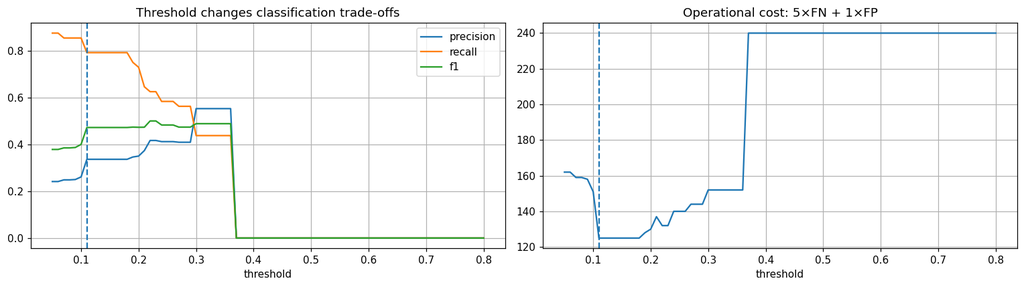

```python
validation_proba = selected_probability_model.predict_proba(X_valid)[:, 1]
thresholds = np.linspace(.05, .80, 76)
rows = []
for t in thresholds:
    pred = (validation_proba >= t).astype(int)
    tn, fp, fn, tp = confusion_matrix(y_valid, pred).ravel()
    rows.append({"threshold": t, "precision": precision_score(y_valid,pred,zero_division=0), "recall": recall_score(y_valid,pred,zero_division=0), "f1": f1_score(y_valid,pred,zero_division=0), "cost": 5*fn + fp})
threshold_table = pd.DataFrame(rows)
chosen_threshold = float(threshold_table.loc[threshold_table["cost"].idxmin(), "threshold"])
print("validation-selected cost-sensitive threshold:", chosen_threshold)
fig, axes = plt.subplots(1, 2, figsize=(14, 4))
threshold_table.plot(x="threshold", y=["precision","recall","f1"], ax=axes[0])
threshold_table.plot(x="threshold", y="cost", ax=axes[1], legend=False)
axes[0].axvline(chosen_threshold, linestyle="--"); axes[1].axvline(chosen_threshold, linestyle="--")
axes[0].set_title("Threshold changes classification trade-offs"); axes[1].set_title("Operational cost: 5×FN + 1×FP")
plt.tight_layout(); plt.show()
```